# Q3 – Do distinct transcriptional signatures converge on common pathways?

Functional enrichment of the pseudobulk differential expression results: ORA, then GSEA (clusterProfiler)

Author

Ann-Solène Adelson

Published

November 18, 2026

**NoteHow to read this notebook**

Each step starts with a short explanation of **what we do and why**, then the code. Every figure comes with:

- a **legend** (“Figure Q3-Fxx”), written so that it can be copied into the report or the appendix;
- a **“How to read”** box, to understand the figure without knowing the method;
- an **“Interpretation”** box, with the HBCC results.

Each figure answers a part of the question. Figures are saved as `.png` (300 dpi) in `04_FIGURES/Q3_enrichment/`, and all the tables in `03_RESULTS/Q3_enrichment/`; the list of figures is at the end of the notebook. References are numbered in square brackets and listed at the end.

# Overview

## Question and hypothesis

**Central question of the project.** Do schizophrenia (SCZ) and bipolar disorder (BD) share cell-type-specific molecular alterations in the human prefrontal cortex, and could these changes reflect accelerated ageing and affect neuronal and glial signalling networks?

**Question of this notebook (Q3).** *Do distinct transcriptional signatures converge on common biological pathways, particularly synaptic and neurotransmission-related ones?*

**Hypothesis tested (H1).** SCZ and BD may affect **the same biological functions**, even if the genes that change are not the same.

## Why move from genes to pathways

Q2 tells us **which genes** change in each cell type. But two diseases can change few genes in common and still disturb the same function: a pathway contains dozens of genes, and each disease may hit a different subset of them. Q3 groups genes into **gene sets** (lists of genes known to work together, for example “synaptic vesicle cycle”) and asks which functions are altered, in SCZ, in BD, and in both.

| Notebook | Answers | Gives to Q3 |
| --- | --- | --- |
| Q1 – altered populations | *where?* which cell types are most affected | the key cell types to look at first |
| Q2 – pseudobulk DE | *what?* which genes change in SCZ and in BD | the table of all tested genes and their statistics |
| **Q3 – this notebook** | *which functions?* do the changes converge on the same pathways | — |
| Q4 – cell communication | *which signals?* | pathways involving ligands / receptors can be checked in Q4 |

## Two methods, used one after the other: ORA, then GSEA

We follow the HBC Training lesson on pseudobulk data [1], which is exactly our Q2 → Q3 situation, with the `clusterProfiler` package [2].

- **ORA (over-representation analysis)** takes the list of significant genes (DEGs) and asks: *does this list contain more genes of a given function than expected by chance?* It is simple and close to the Q2 results, but it depends on the significance threshold.
- **GSEA (gene set enrichment analysis)** [3] takes **all** tested genes, ranked from the most increased to the most decreased, and asks: *are the genes of a function grouped at the top or at the bottom of this ranking?* It needs no threshold and gives a direction (up or down). It can detect a function where many genes change a little, which is exactly what H1 predicts if SCZ and BD reach the same function through different genes.

Results found by **both** methods are the most reliable.

|  | ORA | GSEA |
| --- | --- | --- |
| Input | list of DEGs (adjusted p < 0.05) | all tested genes, ranked |
| Direction of the change | only if up and down genes are tested separately | yes, given by the sign of the NES |
| Detects | functions with several strongly changed genes | functions with many slightly changed genes |
| `clusterProfiler` functions | `enrichGO()`, `enricher()`, `compareCluster()` | `gseGO()`, `GSEA()` |

## Plan

The notebook follows three stages, summarised below: each box is a step and a question, with the figure that answers it.

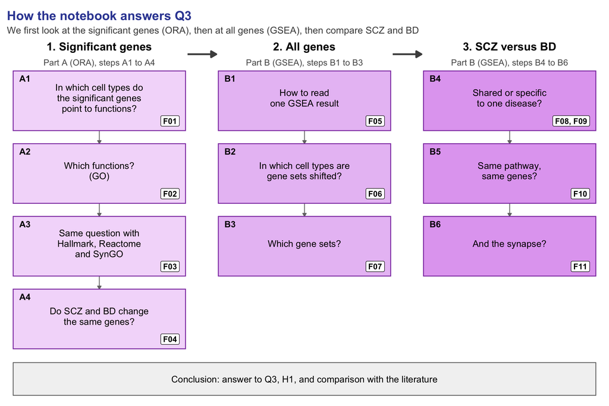

Figure 1

**How the notebook answers Q3.** We first look at the significant genes of Q2 (Part A, ORA), then at all genes, ranked (Part B, GSEA), and finally compare SCZ and BD (Part B, steps B4 to B6). Steps 1 and 2 (the Q2 results and the gene sets tested) come before Part A; the conclusion gathers all the answers.

# Setup

| Package | Used for |
| --- | --- |
| `clusterProfiler` | ORA and GSEA |
| `org.Hs.eg.db` | human gene annotation: links gene symbols to GO terms |
| `dplyr`, `tidyr`, `ggplot2`, `patchwork` | tables and figures (`patchwork` puts several panels in one figure) |

```r
the.seed <- 42          # GSEA uses random permutations: a fixed seed makes the results reproducible
set.seed(the.seed)

suppressPackageStartupMessages({
  library(dplyr)
  library(tidyr)
  library(ggplot2)
  library(patchwork)
  library(clusterProfiler)
  library(org.Hs.eg.db)
})
select <- dplyr::select # org.Hs.eg.db also has a select(): use the dplyr one for tables
# fgsea (used by gseGO/GSEA) runs in parallel by default; on macOS this can freeze the render, so we compute serially
BiocParallel::register(BiocParallel::SerialParam(), default = TRUE)

# Reusable functions, kept outside the notebook so the code below stays readable
source("scripts/utils_genesets.R")
source("scripts/utils_enrichment.R")
source("scripts/utils_figures.R")     # common figure style, colours and saving (shared with the other notebooks)
```

All the choices are gathered in one place, so the analysis can be re-run with other values.

| Parameter | Value | Why |
| --- | --- | --- |
| `alpha` | 0.05 | threshold on the **adjusted** p-value (Benjamini–Hochberg correction, because thousands of tests are done) |
| `min_set_size` / `max_set_size` | 15 / 500 | very small sets give unstable results; very large ones are too vague to interpret |
| `ranking_metric` | `stat` | DESeq2 Wald statistic = log2 fold change divided by its uncertainty. It ranks genes by how **confidently** they change, keeps the direction, and avoids favouring noisy, lowly expressed genes |
| `simplify_cutoff` | 0.7 | GO terms that are too similar are merged, keeping the most significant one |
| `min_genes_term` | 3 | ORA: a function must contain at least 3 significant genes of the list, as in Metascape [4]; with 1 or 2 genes, a function can look enriched by chance alone |
| `example_celltype`, `example_set` | Micro, interferon gamma response | the GSEA result shown in detail in Step B1: shifted in both diseases, in a cell type central to the project |

```r
# Inputs
de_path    <- "../03_RESULTS/Q2/de_results_all.csv"
geneset_dir <- "../01_DATA/genesets"   # one CSV per collection (gs_name, gene_symbol), see its README.md

# Outputs
out_dir <- "../03_RESULTS/Q3_enrichment"
fig_dir <- "../04_FIGURES/Q3_enrichment"
dir.create(out_dir, recursive = TRUE, showWarnings = FALSE)
dir.create(fig_dir, recursive = TRUE, showWarnings = FALSE)
save_figure(p_reasoning, "Q3_reasoning", fig_dir, width = 12, height = 8)   # diagram of the Overview

# Analysis choices
alpha               <- 0.05
min_set_size        <- 15
max_set_size        <- 500
ranking_metric      <- "stat"
simplify_cutoff     <- 0.7
contrast_scz        <- "SCZ_vs_CTRL"
contrast_bd         <- "BD_vs_CTRL"
contrast_direct     <- "SCZ_vs_BD"   # direct comparison of the two disorders (provided by Q2)
min_genes_term      <- 3                  # ORA: minimum number of significant genes in a function
example_celltype    <- "Micro"                                # Step B1: example of a GSEA result
example_set         <- "HALLMARK_INTERFERON_GAMMA_RESPONSE"

# Short labels for the three comparisons
label_contrast <- function(x) {
  factor(dplyr::recode(x, !!contrast_scz := "SCZ", !!contrast_bd := "BD", !!contrast_direct := "SCZ vs BD"),
         levels = c("SCZ", "BD", "SCZ vs BD"))
}
```

## Step 1 – The input: Q2 results

**What we do and why.** Before any enrichment, we check that the Q2 table is complete and see how many genes change in each cell type. The table has one row per gene, cell type and comparison, with the DESeq2 results: `log2FoldChange` (size and direction of the change), `stat` (used to rank genes), and `padj` (p-value adjusted for the number of genes tested). **All tested genes** are kept, not only the significant ones: the GSEA needs the full ranking, and the ORA needs them as the background (“universe”).

```r
de <- load_de_results(de_path)   # stops with a clear message if a column is missing

cell_types <- sort(unique(de$cell_type))
cell_order <- order_cell_types(cell_types)   # excitatory neurons, inhibitory neurons, glia, vascular cells

deg_counts <- de |>
  mutate(disease = label_contrast(contrast)) |>
  group_by(cell_type, disease) |>
  summarise(n_tested = n(),
            up       = sum(padj < alpha & log2FoldChange > 0, na.rm = TRUE),
            down     = sum(padj < alpha & log2FoldChange < 0, na.rm = TRUE),
            .groups  = "drop")
write.csv(deg_counts, file.path(out_dir, "deg_counts.csv"), row.names = FALSE)
```

The number of significant genes per cell type and comparison is saved in `deg_counts.csv` and shown in Figure F01 (A).

**Quick check of the gene ranking.** The GSEA ranks genes by the Wald statistic. If Q2 worked well, most genes do not change, so the statistic should be centred on 0 (median close to 0). A median far from 0 would point to a problem in Q2 (for example a missing covariate).

```r
de |>
  mutate(disease = label_contrast(contrast)) |>
  group_by(cell_type, disease) |>
  summarise(median_stat = round(median(.data[[ranking_metric]], na.rm = TRUE), 2),
            q05 = round(quantile(.data[[ranking_metric]], 0.05, na.rm = TRUE), 2),
            q95 = round(quantile(.data[[ranking_metric]], 0.95, na.rm = TRUE), 2),
            .groups = "drop")
```

| cell_type | disease | median_stat | q05 | q95 |
| --- | --- | --- | --- | --- |
| Astro | SCZ | -0.25 | -1.99 | 2.01 |
| Astro | BD | 0.24 | -1.75 | 2.46 |
| Astro | SCZ vs BD | -0.41 | -1.96 | 1.41 |
| EN_L2_3_IT | SCZ | -0.52 | -2.75 | 2.43 |
| EN_L2_3_IT | BD | 0.35 | -1.51 | 2.47 |
| EN_L2_3_IT | SCZ vs BD | -0.76 | -2.54 | 1.57 |
| EN_L3_5_IT_1 | SCZ | -0.18 | -2.34 | 1.98 |
| EN_L3_5_IT_1 | BD | 0.14 | -1.39 | 1.91 |
| EN_L3_5_IT_1 | SCZ vs BD | -0.29 | -2.20 | 1.53 |
| EN_L3_5_IT_2 | SCZ | -0.04 | -2.25 | 2.16 |
| EN_L3_5_IT_2 | BD | 0.16 | -1.52 | 2.15 |
| EN_L3_5_IT_2 | SCZ vs BD | -0.22 | -1.99 | 1.52 |
| EN_L3_5_IT_3 | SCZ | -0.17 | -2.38 | 2.23 |
| EN_L3_5_IT_3 | BD | 0.18 | -1.55 | 2.21 |
| EN_L3_5_IT_3 | SCZ vs BD | -0.34 | -2.03 | 1.42 |
| EN_L5_6_NP | SCZ | -0.04 | -1.74 | 1.72 |
| EN_L5_6_NP | BD | 0.03 | -1.50 | 1.85 |
| EN_L5_6_NP | SCZ vs BD | -0.08 | -1.71 | 1.48 |
| EN_L6B | SCZ | 0.20 | -1.75 | 1.75 |
| EN_L6B | BD | 0.15 | -1.65 | 1.96 |
| EN_L6B | SCZ vs BD | 0.04 | -1.63 | 1.44 |
| EN_L6_CT | SCZ | 0.02 | -1.78 | 1.80 |
| EN_L6_CT | BD | -0.01 | -1.65 | 1.85 |
| EN_L6_CT | SCZ vs BD | 0.02 | -1.62 | 1.45 |
| EN_L6_IT_1 | SCZ | 0.06 | -1.82 | 1.84 |
| EN_L6_IT_1 | BD | 0.17 | -1.54 | 2.08 |
| EN_L6_IT_1 | SCZ vs BD | -0.11 | -1.81 | 1.41 |
| EN_L6_IT_2 | SCZ | 0.03 | -1.65 | 1.78 |
| EN_L6_IT_2 | BD | 0.14 | -1.59 | 1.96 |
| EN_L6_IT_2 | SCZ vs BD | -0.10 | -1.59 | 1.35 |
| Endo | SCZ | 0.01 | -2.15 | 2.20 |
| Endo | BD | -0.06 | -1.60 | 1.70 |
| Endo | SCZ vs BD | 0.05 | -1.68 | 1.62 |
| IN_ADARB2 | SCZ | -0.07 | -2.14 | 1.86 |
| IN_ADARB2 | BD | 0.14 | -1.42 | 1.84 |
| IN_ADARB2 | SCZ vs BD | -0.18 | -2.04 | 1.41 |
| IN_LAMP5_LHX6 | SCZ | -0.10 | -1.68 | 1.47 |
| IN_LAMP5_LHX6 | BD | 0.11 | -1.40 | 1.95 |
| IN_LAMP5_LHX6 | SCZ vs BD | -0.19 | -1.97 | 1.34 |
| IN_LAMP5_RELN | SCZ | -0.14 | -2.12 | 1.85 |
| IN_LAMP5_RELN | BD | 0.19 | -1.36 | 2.00 |
| IN_LAMP5_RELN | SCZ vs BD | -0.28 | -2.11 | 1.35 |
| IN_PVALB | SCZ | -0.17 | -2.18 | 1.89 |
| IN_PVALB | BD | 0.20 | -1.50 | 2.12 |
| IN_PVALB | SCZ vs BD | -0.35 | -2.14 | 1.43 |
| IN_PVALB_CHC | SCZ | -0.10 | -1.85 | 1.86 |
| IN_PVALB_CHC | BD | 0.15 | -1.39 | 1.88 |
| IN_PVALB_CHC | SCZ vs BD | -0.19 | -1.90 | 1.45 |
| IN_SST | SCZ | -0.12 | -2.40 | 2.02 |
| IN_SST | BD | 0.15 | -1.55 | 1.98 |
| IN_SST | SCZ vs BD | -0.25 | -2.10 | 1.42 |
| IN_VIP | SCZ | -0.16 | -2.36 | 2.14 |
| IN_VIP | BD | 0.08 | -1.56 | 2.04 |
| IN_VIP | SCZ vs BD | -0.23 | -2.08 | 1.56 |
| Micro | SCZ | 0.12 | -1.79 | 1.87 |
| Micro | BD | 0.30 | -1.54 | 2.03 |
| Micro | SCZ vs BD | -0.17 | -1.69 | 1.39 |
| OPC | SCZ | -0.23 | -1.92 | 1.70 |
| OPC | BD | 0.01 | -1.72 | 2.08 |
| OPC | SCZ vs BD | -0.21 | -1.86 | 1.47 |
| Oligo | SCZ | -0.33 | -2.12 | 1.80 |
| Oligo | BD | 0.33 | -1.55 | 2.04 |
| Oligo | SCZ vs BD | -0.52 | -2.09 | 1.36 |
| PC | SCZ | -0.22 | -1.95 | 1.86 |
| PC | BD | -0.15 | -1.89 | 1.88 |
| PC | SCZ vs BD | -0.06 | -1.50 | 1.44 |
| VLMC | SCZ | -0.14 | -1.74 | 1.66 |
| VLMC | BD | 0.01 | -1.38 | 1.46 |
| VLMC | SCZ vs BD | -0.12 | -1.58 | 1.44 |

**TipHow to read**

`median_stat` should be close to 0. `q05` and `q95` give the range of 90 % of the genes: a wider range means a stronger response to the disease.

**ImportantInterpretation**

- The median statistic stays between −0.8 and +0.4 in every cell type and comparison: no cell type is strongly shifted as a whole, so the ranking can be used for GSEA.
- The largest shift is in EN_L2_3_IT (median −0.5 in SCZ vs controls, −0.8 in SCZ vs BD): many genes slightly lower in SCZ in this cell type. We keep it in mind when reading its GSEA results.

## Step 2 – Gene sets: which functions are tested?

**What we do and why.** We use four collections of gene sets, from broad to specialised. P-values are corrected **within each collection**, because the collections overlap and answer different questions.

| Collection | Size | Why |
| --- | --- | --- |
| GO Biological Process | ~7,500 terms | detailed functions; similar terms are merged with `simplify()` |
| MSigDB Hallmark [5] | 50 sets | well-known processes (inflammation, oxidative phosphorylation…): a readable overview |
| Reactome | ~1,600 pathways | signalling and metabolic pathways, including neurotransmission |
| SynGO [6] | expert-curated synaptic genes | direct test of the synaptic part of the question (file in `01_DATA/genesets/`, see its `README.md`) |

GO is read with `org.Hs.eg.db`; Hallmark, Reactome (MSigDB v7.5.1) and SynGO are CSV files included in `01_DATA/genesets/`, so no download is needed. Gene symbols are used everywhere, so no identifier conversion is needed.

```r
# NULL = GO Biological Process, handled by enrichGO / gseGO with org.Hs.eg.db
collections <- list(GO_BP    = NULL,
                    Hallmark = read_geneset_file(file.path(geneset_dir, "Q3_hallmark.csv")),
                    Reactome = read_geneset_file(file.path(geneset_dir, "Q3_reactome.csv")),
                    SynGO    = read_geneset_file(file.path(geneset_dir, "Q3_syngo.csv")))
if (is.null(collections$SynGO)) {
  collections$SynGO <- NULL   # removes the empty entry
  cat("Note: SynGO file not found, Step B6 will be skipped.\n")
}

msigdb_like <- collections[!vapply(collections, is.null, logical(1))]

# How many genes of each set were actually tested in Q2?
tested_genes <- unique(de$gene)
bind_rows(lapply(names(msigdb_like), function(coll) {
  cbind(collection = coll, geneset_coverage(term2gene_to_list(msigdb_like[[coll]]), tested_genes))
})) |>
  group_by(collection) |>
  summarise(n_sets                    = n(),
            median_fraction_present   = round(median(fraction_present), 2),
            sets_with_less_than_50pct = sum(fraction_present < 0.5),
            .groups = "drop")
```

| collection | n_sets | median_fraction_present | sets_with_less_than_50pct |
| --- | --- | --- | --- |
| Hallmark | 50 | 0.95 | 0 |
| Reactome | 1615 | 0.94 | 22 |
| SynGO | 13 | 0.97 | 0 |

**TipHow to read**

A gene set is only reliable if most of its genes were tested in Q2. `median_fraction_present` is the typical fraction of a set’s genes found in our data. Sets with less than 50 % of their genes present are mostly made of genes not expressed in the cortex (for example liver or immune genes). GO is not shown: `clusterProfiler` handles it automatically.

**ImportantInterpretation**

- The coverage is good: a typical gene set has 95 % (Hallmark), 94 % (Reactome) and 97 % (SynGO) of its genes tested in Q2.
- No Hallmark or SynGO set is below 50 %; 22 of the 1,615 Reactome pathways are, and are read with caution.

# Part A – Over-representation analysis (ORA)

**Part A asks the simplest question first.** Q2 gave us, for each cell type, the list of genes that are significantly increased or decreased in patients. If these genes are not random, many of them should belong to the same biological function. Over-representation analysis (ORA) checks this, list by list. We use four lists per cell type (SCZ up, SCZ down, BD up, BD down), because up and down genes may point to opposite functions.

**How ORA works.** Take the significant genes of one list and one function (a gene set, for example “oxidative phosphorylation”). If the function contains 2 % of all tested genes but 10 % of the significant genes, it is **over-represented** (“enriched”): it appears more often than chance would predict. A hypergeometric test (a one-sided Fisher test) says whether this excess is larger than chance. `clusterProfiler` reports it as `GeneRatio` (significant genes in the function / significant genes of the list) against `BgRatio` (tested genes in the function / all tested genes).

**Our choices.**

- Up- and down-regulated genes are tested **separately**: otherwise we could not tell whether a function goes up or down.
- The background (**universe**) is the set of genes tested in Q2 for that cell type, not the whole genome. With the whole genome, every brain function would look enriched, only because genes not expressed in the brain can never be significant.
- `compareCluster()` runs the ORA on the four lists of a cell type together, so SCZ and BD can be compared.
- Lists with fewer than 5 genes are skipped.
- A function is kept only if it contains **at least 3 significant genes** of the list, as in Metascape [4]. With 1 or 2 genes, a function can look enriched by chance alone (one gene out of one is “100 %”), and one or two genes cannot show that a whole function is affected.

```r
# GO Biological Process: enrichGO through compareCluster, then similar terms merged with simplify()
ora_go_table <- bind_rows(lapply(cell_types, function(ct) {
  de_ct <- de[de$cell_type == ct, ]
  res <- run_ora_compare(make_deg_lists(de_ct, alpha, c(SCZ = contrast_scz, BD = contrast_bd)),
                         unique(de_ct$gene), term2gene = NULL, alpha = alpha,
                         min_size = min_set_size, max_size = max_set_size)
  if (is.null(res)) return(NULL)
  cbind(cell_type = ct, as.data.frame(simplify_go(res, cutoff = simplify_cutoff)))
}))

# Hallmark, Reactome and SynGO: enricher through compareCluster
ora_curated_table <- bind_rows(lapply(names(msigdb_like), function(coll) {
  bind_rows(lapply(cell_types, function(ct) {
    de_ct <- de[de$cell_type == ct, ]
    res <- run_ora_compare(make_deg_lists(de_ct, alpha, c(SCZ = contrast_scz, BD = contrast_bd)),
                           unique(de_ct$gene), term2gene = msigdb_like[[coll]], alpha = alpha,
                           min_size = min_set_size, max_size = max_set_size)
    if (is.null(res)) return(NULL)
    cbind(collection = coll, cell_type = ct, as.data.frame(res))
  }))
}))

# Keep only the functions supported by at least min_genes_term significant genes
ora_go_table      <- filter(ora_go_table, Count >= min_genes_term)
ora_curated_table <- filter(ora_curated_table, Count >= min_genes_term)

write.csv(ora_go_table, file.path(out_dir, "ora_go_bp.csv"), row.names = FALSE)
write.csv(ora_curated_table, file.path(out_dir, "ora_curated.csv"), row.names = FALSE)
```

The full ORA results (all functions, all cell types, with their genes in the column `geneID`) are saved in `03_RESULTS/Q3_enrichment/ora_go_bp.csv` and `ora_curated.csv`. The notebook shows them as figures.

## Step A1 – Where does ORA find something?

**What we do and why.** Before looking at the functions themselves, we count, for each cell type, the significant genes (A) and the number of functions ORA finds among them (B). This tells us where Part A has something to say.

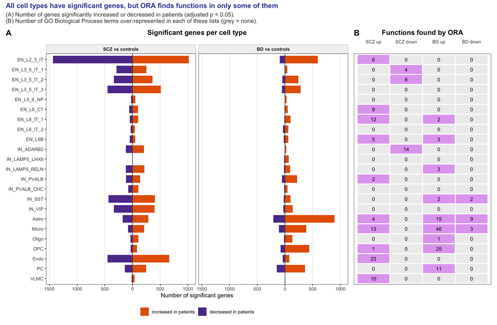

Figure 2

```r
p_F01 <- plot_ora_overview(deg_counts, ora_go_table, cell_order)
p_F01
save_figure(p_F01, "Q3_F01_ORA_overview", fig_dir, width = 13, height = 8.5)
```

**Figure Q3-F01 – Significant genes and functions found by ORA, per cell type.** (A) Number of genes significantly increased (orange) or decreased (purple) in SCZ and in BD compared with controls (DESeq2, adjusted p < 0.05). (B) Number of GO Biological Process terms over-represented (ORA, adjusted p < 0.05, at least 3 genes, similar terms merged) in each of the four lists.

**TipHow to read**

1. One row per cell type: bars to the right = genes increased in patients, to the left = genes decreased. (B) Same rows, one column per list: the number of functions found in that list. A grey box means that ORA found no function, even if the list contains many genes.

## Step A2 – Which functions? (GO Biological Process)

**What we do and why.** For each cell type, we show the 3 most significant functions of each list. One figure per family of cell types (excitatory neurons, inhibitory neurons, glial cells, vascular cells), one panel per cell type, so that each figure can be read on its own in the report or the slides.

```r
F02_files <- save_ora_family_figures(ora_go_table, "GO Biological Process", "Q3_F02_ORA_GO",
                                     cell_order, fig_dir)
```

**Excitatory neurons**

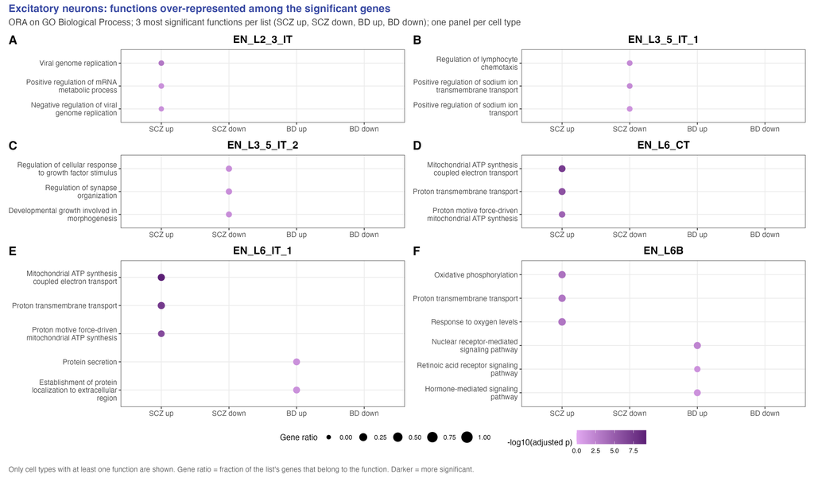

**Inhibitory neurons**

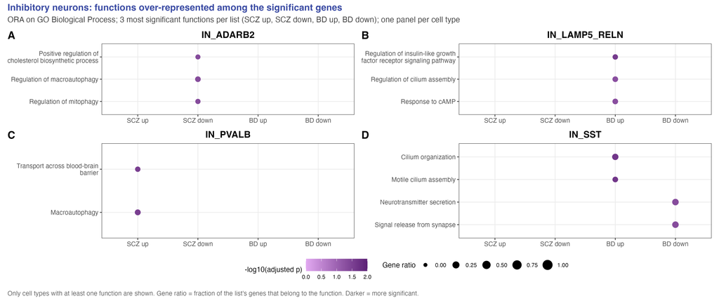

**Glial cells**

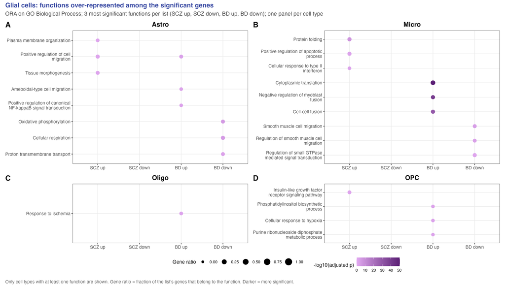

**Vascular cells**

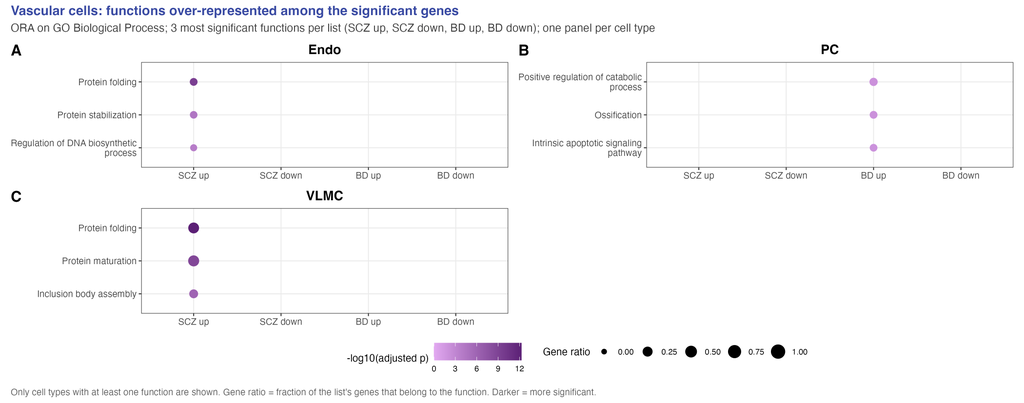

**Figure Q3-F02 – Functions over-represented among the significant genes (GO Biological Process), one panel per cell type.** One figure per family of cell types (tabs). For each cell type, the 3 most significant GO terms of each list (ORA, `enrichGO` through `compareCluster`, adjusted p < 0.05, at least 3 genes, similar terms merged with `simplify`, cutoff 0.7). Dot size: gene ratio; colour: −log10(adjusted p). Cell types without any function are not shown (see F01 B).

**TipHow to read**

Click on a tab to choose the family of cell types. In each panel (A, B, C…), the columns are the four lists and the rows are functions. A dot means that the function is over-represented in that list. Bigger dot = larger share of the list in the function; darker = more significant. A function with a dot in both `SCZ up` and `BD up` (or both `down`) is changed in the same way by both diseases.

**ImportantInterpretation**

- **Energy production by mitochondria** (oxidative phosphorylation, ATP synthesis) is increased in SCZ in deep-layer neurons (EN_L6B, EN_L6_CT, EN_L6_IT_1), and decreased in BD in astrocytes.
- **Protein folding**, a stress response, is increased in SCZ in microglia and in vascular cells (Endo, VLMC).
- **Synaptic functions are rare**: only synapse organisation (down in SCZ, EN_L3_5_IT_2) and neurotransmitter secretion (down in BD, IN_SST).
- **The same function is almost never found in SCZ and BD in the same cell type**: the only case is “cell migration”, up in both in astrocytes. At this level, there is little sign of convergence.
- In microglia, the genes increased in BD give terms named after muscle (myoblast fusion). They come from genes that also act outside muscle: we read them with caution.

## Step A3 – Same question with Hallmark, Reactome and SynGO

**What we do and why.** GO is very detailed. The three other collections give complementary views: Hallmark groups the results into 50 well-known processes, Reactome describes signalling and metabolic pathways, and SynGO is limited to the synapse. The figures have the same layout as F02.

```r
F03_files <- lapply(setNames(names(msigdb_like), names(msigdb_like)), function(coll) {
  save_ora_family_figures(filter(ora_curated_table, collection == coll), coll,
                          paste0("Q3_F03_ORA_", coll), cell_order, fig_dir)
})
```

**Hallmark**

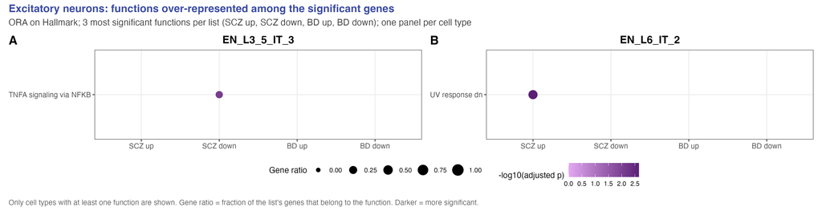

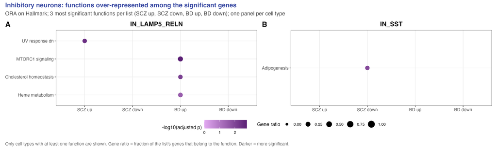

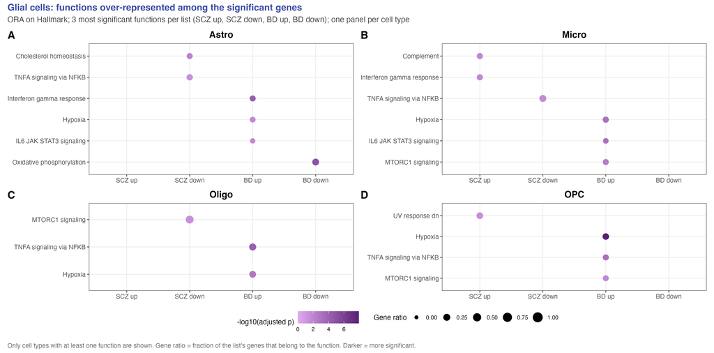

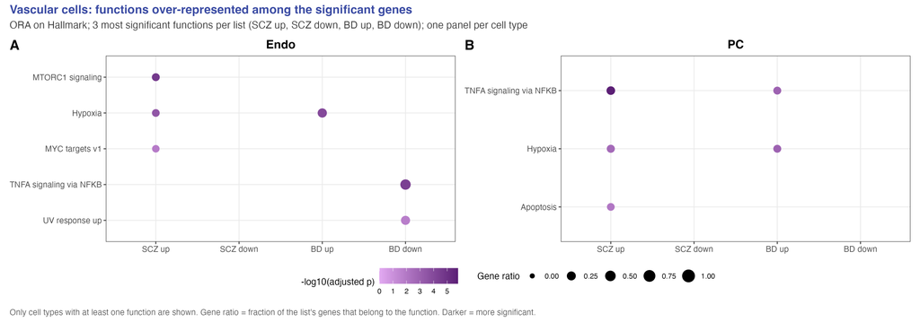

**Reactome**

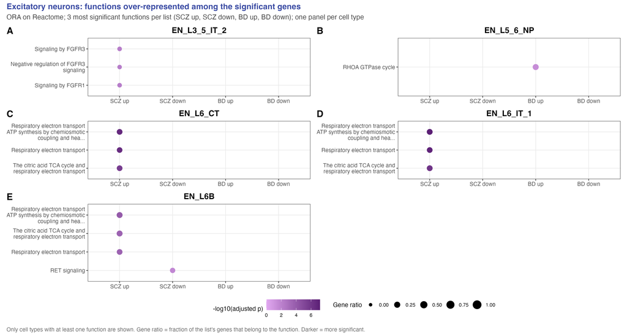

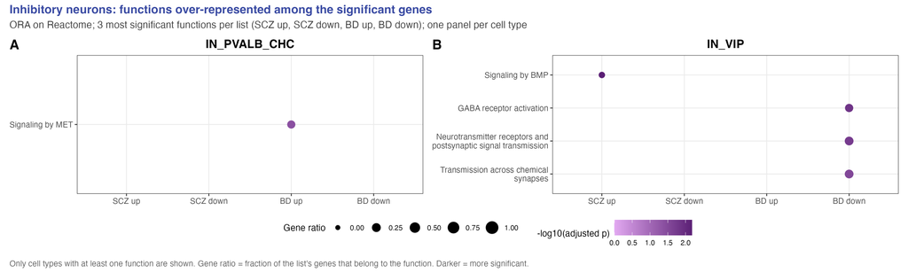

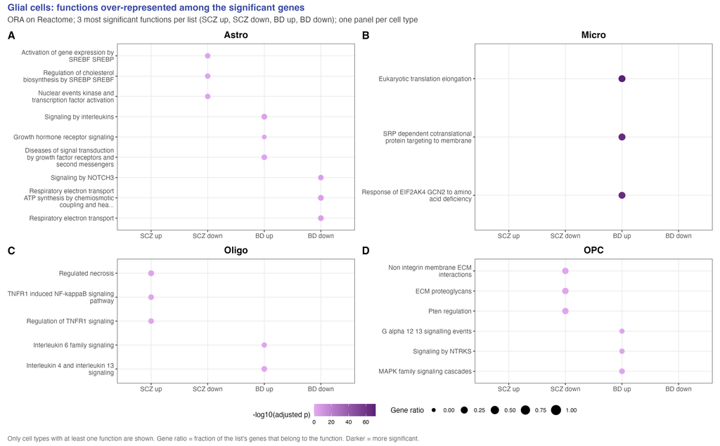

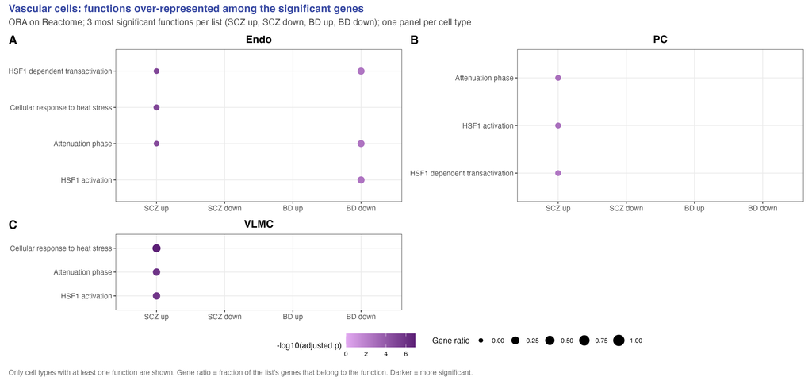

**SynGO**

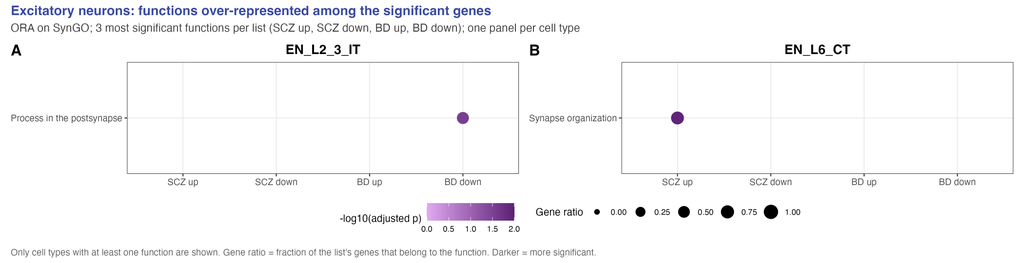

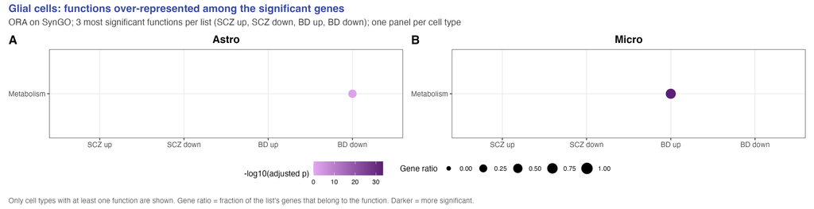

**Figure Q3-F03 – Functions over-represented among the significant genes (Hallmark, Reactome, SynGO).** One tab per collection, one figure per family of cell types, one panel per cell type. ORA with `enricher` through `compareCluster`, adjusted p < 0.05, at least 3 genes; 3 most significant sets per list.

**TipHow to read**

Same reading as F02. Click on a tab to choose the collection; the figures of the different families follow each other.

**ImportantInterpretation**

- **Hallmark** groups the results into a few well-known processes: inflammation (TNFA signalling via NFKB, interferon gamma, IL6), low oxygen (hypoxia) and growth signalling (mTORC1). They appear in glial cells (Astro, Micro, OPC, Oligo: mostly BD up) and vascular cells (Endo, PC: SCZ up). These are the **same processes in both diseases**, but rarely in the same cell type and list.
- **Reactome** confirms GO: mitochondrial respiration up in SCZ in deep-layer neurons, heat-stress response up in SCZ in vascular cells. It also finds a synaptic signal: GABA receptor activation and synaptic transmission are down in BD in IN_VIP.
- **SynGO**, the synaptic collection, gives almost no result: **ORA is nearly blind to the synaptic part of our question.**

## Step A4 – Do SCZ and BD change the same genes?

**What we do and why.** Before comparing functions between the two diseases, we measure how much they share at the **gene** level. Each significant gene of a cell type is classified as significant in both diseases in the same direction (shared), in one disease only, or in both with opposite directions. The overlap is summarised by the **Jaccard index**: shared genes / all significant genes (0 = no gene in common, 1 = identical lists). H1 predicts a low overlap of genes, but a larger overlap of functions (Part B). Q2 already describes shared and specific genes; here we compute the value that Figure F10 compares with the pathway level.

```r
deg_status <- de |>
  filter(contrast %in% c(contrast_scz, contrast_bd)) |>
  mutate(direction = case_when(padj < alpha & log2FoldChange > 0 ~ "up",
                               padj < alpha & log2FoldChange < 0 ~ "down",
                               TRUE ~ "ns"),
         contrast = recode(contrast, !!contrast_scz := "SCZ", !!contrast_bd := "BD")) |>
  select(cell_type, gene, contrast, direction) |>
  pivot_wider(names_from = contrast, values_from = direction, values_fill = "ns") |>
  mutate(group = case_when(SCZ != "ns" & SCZ == BD ~ "shared",
                           SCZ != "ns" & BD == "ns" ~ "SCZ_only",
                           SCZ == "ns" & BD != "ns" ~ "BD_only",
                           SCZ != "ns" & BD != "ns" ~ "opposite",
                           TRUE ~ "ns"))

deg_overlap <- deg_status |>
  filter(group != "ns") |>
  count(cell_type, group) |>
  pivot_wider(names_from = group, values_from = n, values_fill = 0)
for (g in c("shared", "SCZ_only", "BD_only", "opposite")) if (!g %in% names(deg_overlap)) deg_overlap[[g]] <- 0
deg_overlap <- deg_overlap |>
  mutate(n_DEG = shared + SCZ_only + BD_only + opposite,
         jaccard_DEG = round(shared / n_DEG, 2))
write.csv(deg_overlap, file.path(out_dir, "deg_overlap.csv"), row.names = FALSE)
```

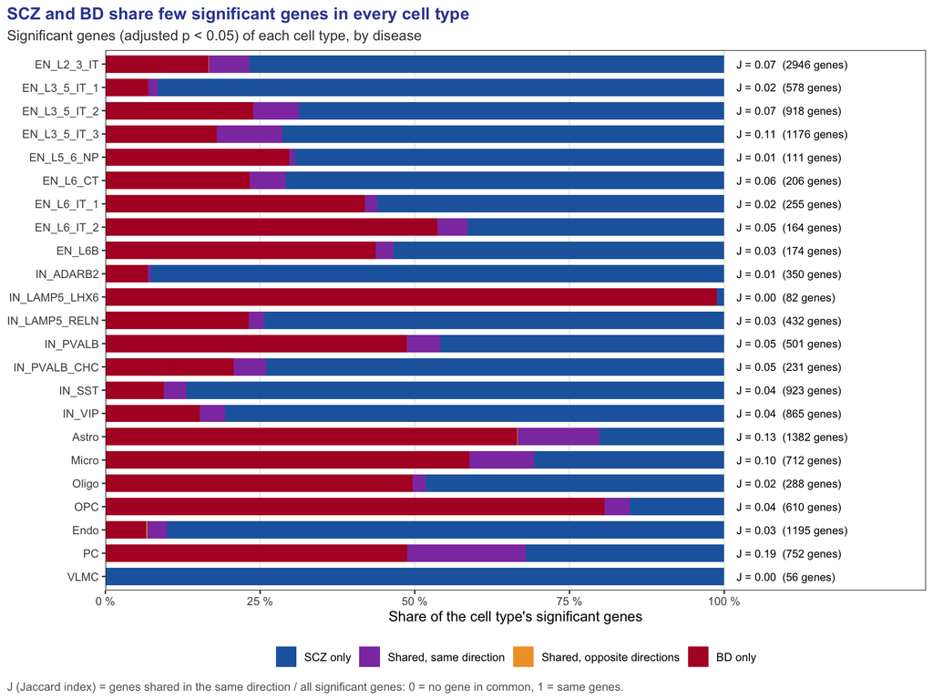

Figure 3

```r
p_F04 <- plot_deg_overlap(deg_overlap, cell_order)
p_F04
save_figure(p_F04, "Q3_F04_DEG_overlap", fig_dir, width = 10, height = 7.5)
```

**Figure Q3-F04 – Overlap of the significant genes of SCZ and BD, per cell type.** For each cell type, share of its significant genes (DESeq2, adjusted p < 0.05, SCZ or BD vs controls) that are significant in SCZ only, in BD only, in both with the same direction, or in both with opposite directions. J = Jaccard index (shared in the same direction / all significant genes); number of significant genes in brackets.

**TipHow to read**

One bar per cell type, split into four colours: blue = SCZ only, red = BD only, purple = shared with the same direction, orange = shared with opposite directions. The larger the purple part (and J), the more the two diseases change the same genes.

**ImportantInterpretation**

- The two diseases share **very few genes**: J is below 0.10 in 19 of the 23 cell types.
- The highest values are in PC (0.19), Astro (0.13), EN_L3_5_IT_3 (0.11) and Micro (0.10).
- Opposite changes are almost absent: when a gene changes in both diseases, it goes the same way.

## What Part A tells us, and why we need Part B

At the gene level, SCZ and BD look different (F04). ORA finds functions in only part of the lists, rarely the same in both diseases, and almost no synaptic function (F01–F03). But ORA has a blind spot: it only uses the genes above the significance threshold. If a disease changes **many genes of a function a little**, none of them passes the threshold and ORA sees nothing. This is exactly what H1 predicts: two diseases reaching the same function through different, modest changes. Part B therefore uses a method that looks at **all** genes, without a threshold: GSEA. This is also the approach of the PsychAD study, which tested gene sets on the statistics of all genes [7].

# Part B – Gene set enrichment analysis (GSEA)

**Part B looks at all genes, without a threshold.** Part A only used the genes above the significance threshold. GSEA uses every tested gene, so it can see a function in which many genes change a little.

**How GSEA works.** All tested genes of a cell type are ranked from the most increased to the most decreased in patients (DESeq2 Wald statistic). For one gene set, we look at where its genes fall in this ranking. If they are grouped at the top, the set is **shifted up** in the disease; at the bottom, **shifted down**; if they are scattered, nothing happens. Technically, the method walks down the ranking with a running score that goes up at each gene of the set and down otherwise; the peak of this score is the enrichment score [3].

**Which number we read, and why.** GSEA gives four values for each gene set:

| Value | What it says | Why we do not read it alone |
| --- | --- | --- |
| ES (enrichment score) | the peak of the running score: are the genes of the set grouped at the top or at the bottom? | it depends on the size of the set, so a set of 20 genes cannot be compared with a set of 400 |
| **NES** (normalised enrichment score) | the same score, corrected for the size of the set | **it is the only score that can be compared between gene sets, cell types and diseases** |
| adjusted p-value | is this grouping stronger than chance (random permutations, Benjamini–Hochberg correction)? | it says whether the result is reliable, not its direction or its strength |
| leading edge | the genes before the peak, which drive the result | used in Step B5 |

We read the **NES for the direction and the strength** (orange = shifted up, purple = shifted down) and the **adjusted p-value to know whether the shift is significant** (the stars of the figures). The NES is the right summary here because the whole question is a comparison: SCZ against BD, and one cell type against another.

**Our choices.**

- `gseGO()` for GO, `GSEA()` for Hallmark, Reactome and SynGO.
- All tested sets are kept (`pvalueCutoff = 1`), so SCZ and BD can be compared on exactly the same sets; the 0.05 threshold is applied afterwards.
- `eps = 1e-10` (default value): p-values smaller than 10⁻¹⁰ are reported as 10⁻¹⁰, which does not change any conclusion; fixed seed for reproducibility.
- The same GSEA is run on the direct `SCZ_vs_BD` comparison (Step B4).

```r
gsea_all <- lapply(names(collections), function(coll) {
  res <- run_gsea_all(de, collections[[coll]],
                      metric   = ranking_metric,
                      min_size = min_set_size,
                      max_size = max_set_size,
                      seed     = the.seed)
  if (!is.null(res)) res$collection <- coll
  res
}) |>
  bind_rows() |>
  mutate(disease = label_contrast(contrast))

write.csv(gsea_all, file.path(out_dir, "gsea_all.csv"), row.names = FALSE)

gsea_counts <- gsea_all |>
  group_by(collection, cell_type, disease) |>
  summarise(n_tested = n(),
            up       = sum(p.adjust < alpha & NES > 0),
            down     = sum(p.adjust < alpha & NES < 0),
            .groups  = "drop")
write.csv(gsea_counts, file.path(out_dir, "gsea_counts.csv"), row.names = FALSE)
```

The full results (every gene set, cell type and comparison, with NES, adjusted p-value and leading-edge genes) are saved in `gsea_all.csv`, and the number of shifted sets per cell type in `gsea_counts.csv`.

## Step B1 – How to read one GSEA result

**What we do and why.** Before looking at summaries, we look at one result in detail, to see what the NES and the leading edge are. We take a result that matters for the rest of the notebook: the **interferon gamma response in microglia, in SCZ** (shifted in the same direction in SCZ and BD, in a cell type central to the project).

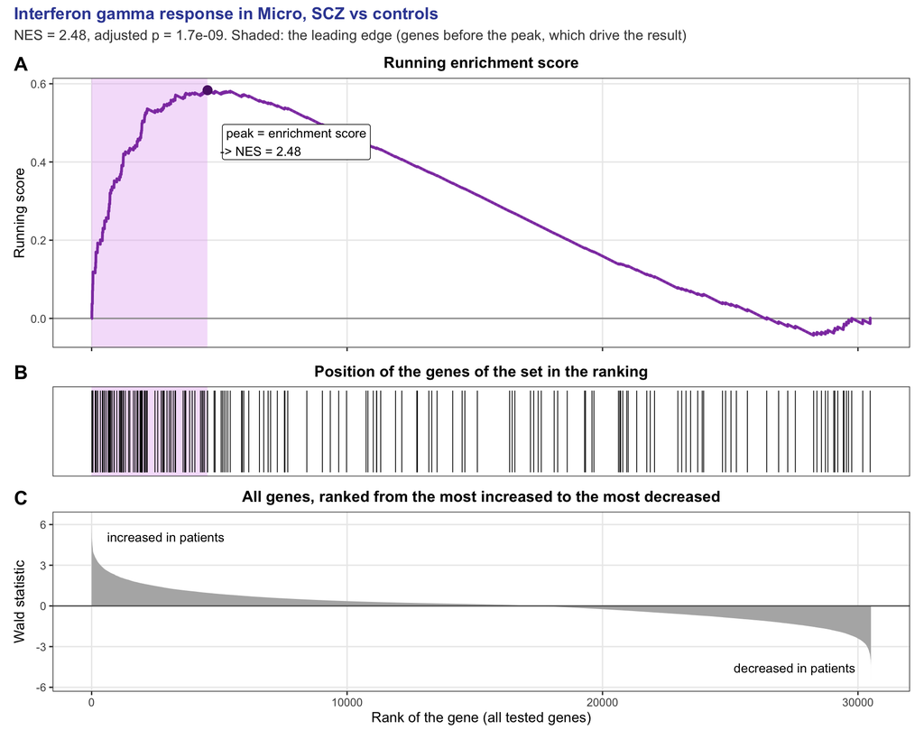

Figure 4

```r
ex_hit <- gsea_all |>
  filter(collection == "Hallmark", cell_type == example_celltype, disease == "SCZ", ID == example_set)
ex_ranks <- make_ranked_list(de[de$cell_type == example_celltype & de$contrast == contrast_scz, ], ranking_metric)
ex_genes <- collections$Hallmark$gene_symbol[collections$Hallmark$gs_name == example_set]

p_F05 <- plot_gsea_example(ex_ranks, ex_genes,
                           title = paste0(clean_set_name(example_set), " in ", example_celltype, ", SCZ vs controls"),
                           nes = ex_hit$NES, padj = ex_hit$p.adjust)
p_F05
save_figure(p_F05, "Q3_F05_GSEA_example", fig_dir, width = 10, height = 8)
```

**Figure Q3-F05 – How to read a GSEA result.** Hallmark “interferon gamma response” in microglia, SCZ vs controls. (A) Running enrichment score along the ranked list of all tested genes; its peak is the enrichment score, normalised into the NES. (B) Position of the genes of the set in the ranking. (C) Ranking statistic (DESeq2 Wald statistic), from the genes most increased in patients (left) to the most decreased (right). Shaded: leading edge.

**TipHow to read**

**ImportantInterpretation**

## Step B2 – Where? Number of shifted gene sets per cell type

**What we do and why.** We count, for each cell type and disease, the gene sets significantly shifted up or down. This is the GSEA counterpart of Figure F01 (A): it tells us which cell types are the most affected at the level of functions.

```r
F06_files <- lapply(setNames(nm = c("Hallmark", "GO_BP", "Reactome")), function(coll) {
  save_figure(plot_gsea_counts(gsea_all, coll, cell_order, alpha), paste0("Q3_F06_GSEA_counts_", coll),
              fig_dir, width = 10, height = 7.5)
})
```

**Hallmark**

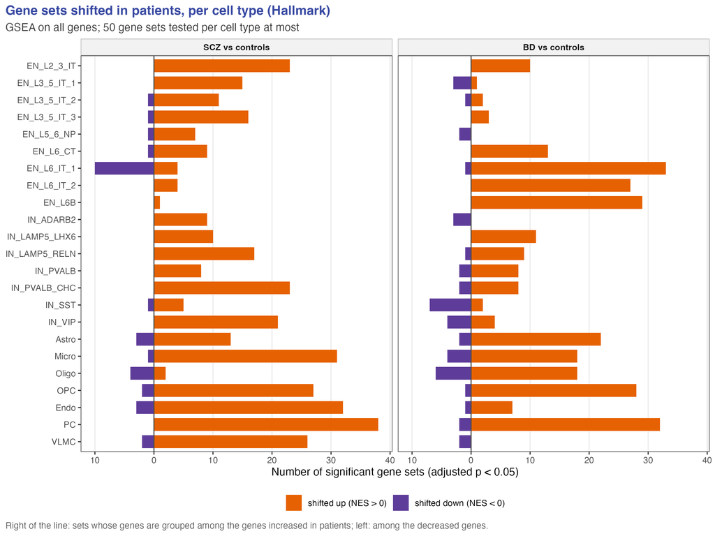

**GO_BP**

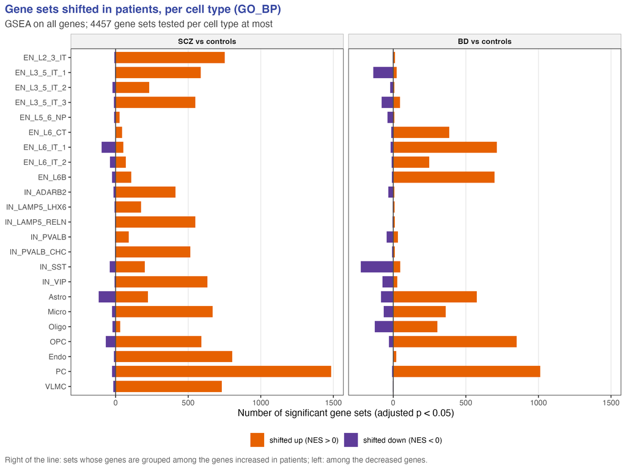

**Reactome**

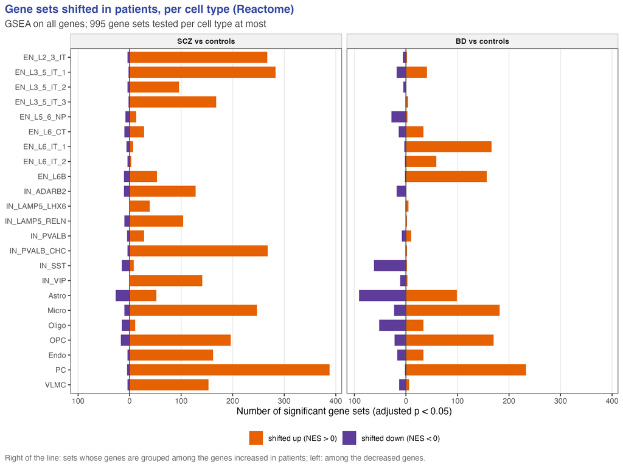

**Figure Q3-F06 – Number of gene sets shifted in patients, per cell type.** GSEA, adjusted p < 0.05, SCZ vs controls (left) and BD vs controls (right). Orange: sets shifted up (NES > 0); purple: shifted down (NES < 0). One tab per collection (Hallmark: 50 sets; GO Biological Process; Reactome).

**TipHow to read**

One row per cell type. Bars to the right count the gene sets whose genes are grouped among the genes increased in patients; bars to the left, among the decreased genes. Compare with F01 (A), which counts single genes.

**ImportantInterpretation**

- GSEA finds shifted gene sets in **all 23 cell types**, including those where ORA found nothing (F01).
- **Almost all of them are shifted up.**
- The most affected cell types differ between the two diseases. In SCZ, these are upper-layer neurons (EN_L2_3_IT) and CGE interneurons (IN_VIP, IN_PVALB_CHC); in BD, deep-layer neurons (EN_L6B, EN_L6_IT_1, EN_L6_IT_2). Glial cells (Micro, OPC) and vascular cells (PC) are affected in both.
- EN_L6B has few significant genes (F01) but 29 shifted Hallmark sets in BD: many small, coordinated changes, which only GSEA can see.

## Step B3 – Which gene sets?

**What we do and why.** We now name the gene sets. To keep the figure readable, we show the **30 gene sets significant in the largest number of cell types** (in SCZ or BD). Rows with similar profiles are placed next to each other (hierarchical clustering). All the results are in `gsea_all.csv`.

```r
F07_files <- lapply(setNames(nm = c("Hallmark", "GO_BP", "Reactome")), function(coll) {
  save_figure(plot_gsea_heatmap(gsea_all, coll, cell_order, n_sets = 30, alpha = alpha),
              paste0("Q3_F07_NES_heatmap_", coll), fig_dir, width = 17, height = 10)
})
```

**Hallmark**

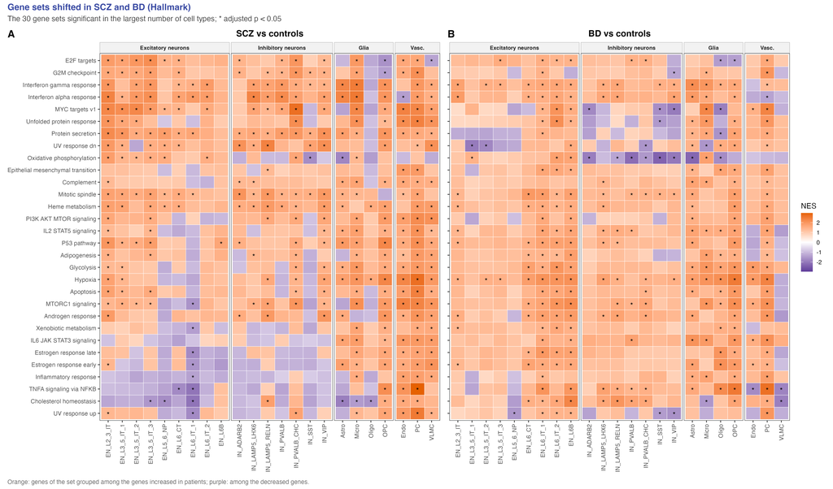

**GO_BP**

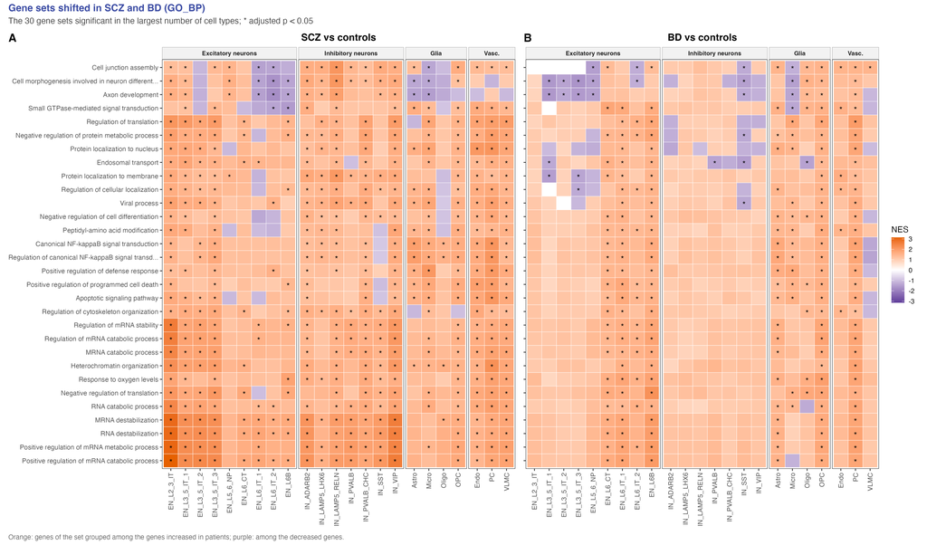

**Reactome**

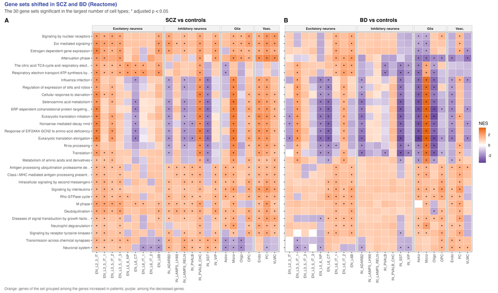

**Figure Q3-F07 – Gene sets shifted in SCZ (A) and BD (B).** NES (colour) of the 30 gene sets significant in the largest number of cell types, per cell type grouped by family. Orange: shifted up; purple: shifted down; * adjusted p < 0.05. One tab per collection.

**TipHow to read**

Read the figure row by row: a row with the same colour, and stars, in panels A and B is a function changed in the same way in both diseases. A row orange in one panel and purple in the other is a function changed in opposite directions.

**ImportantInterpretation**

- The **same processes** come up in both diseases and in many cell types, almost always shifted up: interferon responses, hypoxia, mTORC1 signalling, protein secretion, cell cycle (E2F targets, mitotic spindle), P53 pathway.
- Main exceptions: oxidative phosphorylation is shifted up in SCZ in upper-layer neurons, but down in BD in interneurons and astrocytes; TNFA signalling via NFKB goes up mainly in vascular cells.

## Step B4 – Together or separately? Shared and disease-specific gene sets

**What we do and why.** For each cell type and gene set, we put the SCZ and BD results side by side and classify the set. A pathway significant in SCZ but not in BD is not necessarily specific to SCZ: BD may show the same change, but with fewer donors it does not reach the threshold. To say that the two disorders **differ**, they must be compared **directly**: Q2 provides this comparison (`SCZ_vs_BD`, patients compared with each other, with the same covariates), and we ran the same GSEA on it. A disease-specific pathway is therefore called **confirmed** only if the direct test is also significant.

| Category | Rule | Meaning |
| --- | --- | --- |
| Shared, same direction | significant in both diseases vs controls, same sign of NES | common alteration |
| Shared, opposite directions | significant in both, opposite signs | same function, opposite effects |
| SCZ only (or BD only), confirmed | significant in one disease only **and** in the direct SCZ vs BD test | the two disorders differ |
| SCZ only (or BD only), not confirmed | significant in one disease only, direct test not significant | seen in one disease, but no evidence of a difference |
| Not significant | significant in neither | no evidence |

We also compare the **whole profiles**, beyond the significant sets: the Spearman correlation (rho) of the NES of all tested sets in SCZ and in BD. rho close to 1 means that the two diseases shift the same functions in the same direction, even below the significance threshold.

```r
paired <- gsea_all |>
  group_by(collection) |>
  group_modify(~ pair_contrasts(.x, contrast_scz, contrast_bd)) |>
  ungroup() |>
  classify_pathways(alpha = alpha)

# Add the direct SCZ vs BD test
direct <- gsea_all |>
  filter(contrast == contrast_direct) |>
  select(collection, cell_type, ID, NES_direct = NES, p.adjust_direct = p.adjust)
paired <- paired |>
  left_join(direct, by = c("collection", "cell_type", "ID")) |>
  mutate(differs_SCZ_BD = !is.na(p.adjust_direct) & p.adjust_direct < alpha,
         group = case_when(
           category == "shared_concordant" ~ "Shared, same direction",
           category == "shared_opposite"   ~ "Shared, opposite directions",
           category == "SCZ_specific" & differs_SCZ_BD  ~ "SCZ only, confirmed",
           category == "SCZ_specific" & !differs_SCZ_BD ~ "SCZ only, not confirmed",
           category == "BD_specific"  & differs_SCZ_BD  ~ "BD only, confirmed",
           category == "BD_specific"  & !differs_SCZ_BD ~ "BD only, not confirmed",
           TRUE ~ "Not significant"))
write.csv(paired, file.path(out_dir, "gsea_scz_vs_bd.csv"), row.names = FALSE)

nes_cor <- paired |>
  group_by(collection, cell_type) |>
  summarise(spearman_rho = round(cor(NES_SCZ, NES_BD, method = "spearman"), 2), n_sets = n(), .groups = "drop")
write.csv(nes_cor, file.path(out_dir, "nes_correlation_scz_bd.csv"), row.names = FALSE)
```

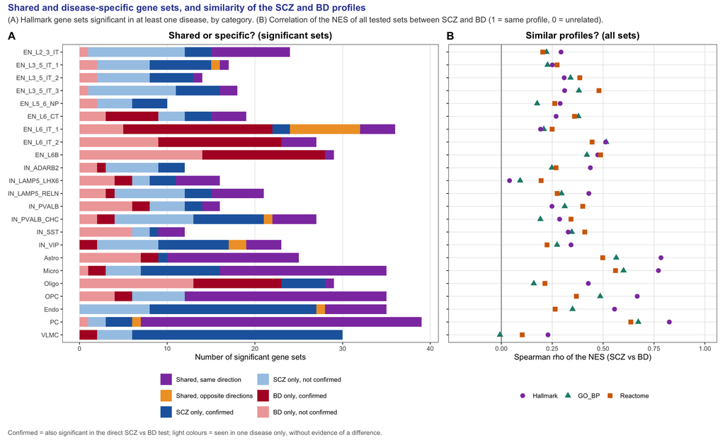

Figure 5

```r
p_F08 <- plot_shared_specific(paired, "Hallmark", cell_order)
p_F08
save_figure(p_F08, "Q3_F08_shared_specific", fig_dir, width = 14, height = 8.5)
```

**Figure Q3-F08 – Shared and disease-specific gene sets, and similarity of the SCZ and BD profiles.** (A) Hallmark gene sets significant (GSEA, adjusted p < 0.05) in at least one disease compared with controls, per cell type and category: shared with the same direction (purple), shared with opposite directions (orange), SCZ only (blue) or BD only (red); dark = confirmed by the direct SCZ vs BD test, light = not confirmed. (B) Spearman correlation of the NES of all tested gene sets between SCZ and BD, per cell type and collection.

**TipHow to read**

1. A large purple part means that many functions are changed in the same way in both diseases. Only the **dark** blue and red parts are gene sets that truly differ between the two disorders; the light parts are seen in one disease only, without evidence of a difference. (B) A dot close to 1 means that the two diseases have the same profile in that cell type; close to 0, unrelated profiles.

**ImportantInterpretation**

- 1. In astrocytes, microglia, OPC and pericytes, most significant gene sets are **shared**. In neurons, gene sets significant in one disease only dominate: SCZ-only sets are mostly in upper-layer neurons and interneurons, BD-only sets in deep-layer neurons (EN_L6B, EN_L6_IT_1, EN_L6_IT_2).
- 2. The whole profiles are most alike in Astro, Micro, OPC and PC (rho 0.67–0.83 with Hallmark), and less in neurons (rho 0.04–0.51). The three collections agree.
- At the gene level (Q2), the fold changes of SCZ and BD correlate only modestly (rho 0.19–0.54); at the pathway level, the correlation is higher in 18 of 23 cell types, most of all in glia (Astro 0.24 → 0.78, OPC 0.26 → 0.67): the convergence is stronger at the level of functions than of genes, as H1 predicts.

**Which gene sets truly differ between SCZ and BD?** The direct comparison, on the same gene sets as F07.

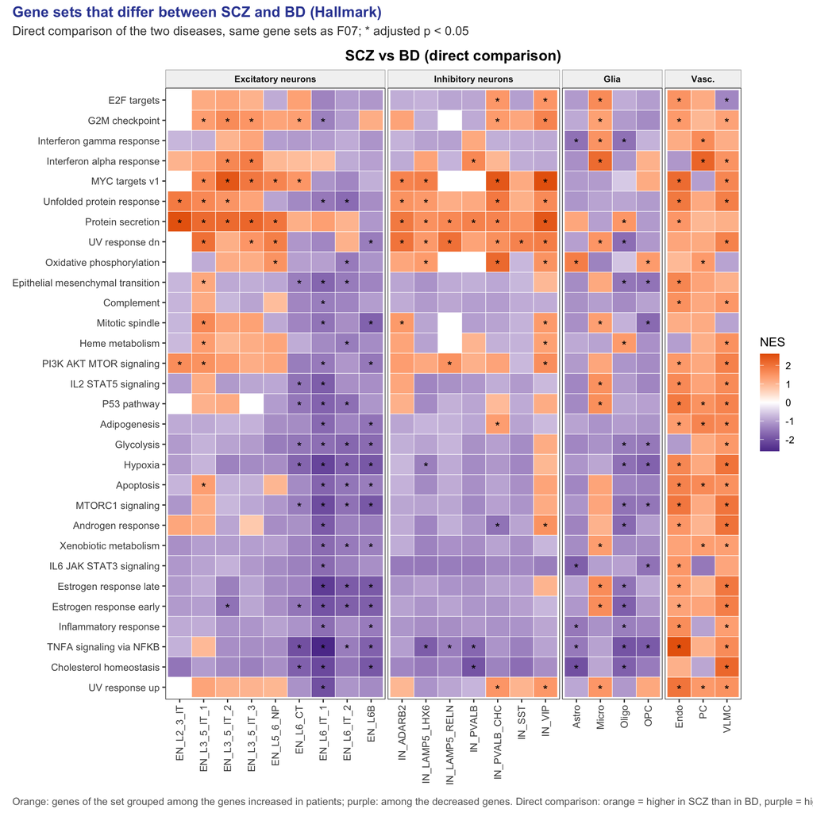

Figure 6

```r
p_F09 <- plot_gsea_heatmap(gsea_all, "Hallmark", cell_order, n_sets = 30, alpha = alpha, diseases = "SCZ vs BD",
                           title = "Gene sets that differ between SCZ and BD (Hallmark)",
                           subtitle = "Direct comparison of the two diseases, same gene sets as F07; * adjusted p < 0.05")
p_F09
save_figure(p_F09, "Q3_F09_direct_SCZ_vs_BD", fig_dir, width = 10, height = 10)
```

**Figure Q3-F09 – Gene sets that differ between SCZ and BD.** NES of the direct SCZ vs BD comparison (patients compared with each other) for the 30 Hallmark sets of F07. Orange: higher in SCZ than in BD; purple: higher in BD than in SCZ; * adjusted p < 0.05.

**TipHow to read**

Only the stars matter for a conclusion: they mark a gene set that differs significantly between the two diseases in that cell type. Without a star, the two diseases cannot be told apart for that set.

**ImportantInterpretation**

- The confirmed differences follow the split of F08. Protein secretion, MYC targets and the unfolded protein response are higher in SCZ in upper-layer neurons and interneurons.
- Hypoxia, mTORC1 and TNFA signalling are higher in BD in deep-layer neurons (EN_L6B, EN_L6_CT, EN_L6_IT_1).
- In vascular cells (Endo, VLMC), many processes are higher in SCZ.

## Step B5 – Same pathway, same genes? (direct test of H1)

**What we do and why.** For a pathway shifted in the same direction in both diseases, we look at the genes that drive it (its leading edge) in SCZ and in BD, and measure their overlap with the Jaccard index:

$$J = \frac{\text{genes driving the pathway in both diseases}}{\text{genes driving it in at least one disease}}$$

J = 0: completely different genes; J = 1: the same genes. For example, the interferon gamma response in microglia (F05) has 187 tested genes; 90 drive it in SCZ and 65 in BD, 46 of them in both: J = 46 / 109 = 0.42.

To judge whether J is large, we need a reference: if each disease picked its driving genes **at random** inside the pathway, they would still share some genes by coincidence. With a genes in SCZ and b in BD among the n genes of the pathway, they would share on average a × b / n genes; this gives the **J expected by chance** (0.25 in the example). For each cell type, we compare the observed and expected J of its shared pathways with a **paired two-sided Wilcoxon signed-rank test**: paired, because both values come from the same pathway; non-parametric, because J is bounded between 0 and 1 and not normally distributed. P-values are corrected over the 23 cell types (Benjamini–Hochberg).

```r
shared <- paired |>
  filter(category == "shared_concordant") |>
  add_leading_edge_overlap() |>
  add_expected_jaccard(gsea_all)
write.csv(shared, file.path(out_dir, "shared_sets_leading_edge.csv"), row.names = FALSE)

le_test <- test_leading_edge(shared)
write.csv(le_test, file.path(out_dir, "leading_edge_test.csv"), row.names = FALSE)
```

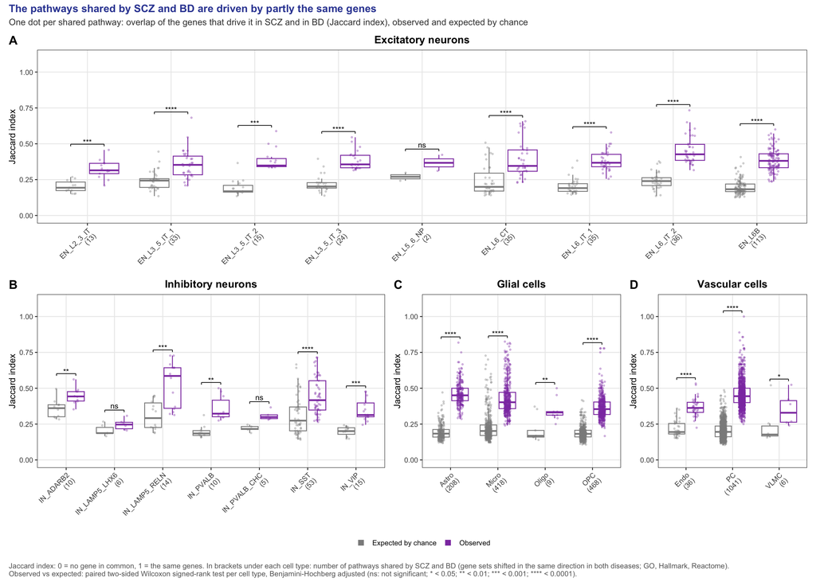

Figure 7

```r
p_F10 <- plot_leading_edge(shared, le_test, cell_order, alpha = alpha, seed = the.seed)
p_F10
save_figure(p_F10, "Q3_F10_leading_edge_overlap", fig_dir, width = 14, height = 10)
```

**Figure Q3-F10 – Overlap of the genes driving the pathways shared by SCZ and BD.** For each pathway shifted in the same direction in both diseases (GO, Hallmark, Reactome), Jaccard index between its leading-edge genes in SCZ and in BD (purple), and the value expected if each disease picked its driving genes at random inside the pathway (grey). One dot per pathway. (A) Excitatory neurons, (B) inhibitory neurons, (C) glial cells, (D) vascular cells; in brackets, the number of shared pathways. Paired two-sided Wilcoxon signed-rank test per cell type, Benjamini–Hochberg adjusted (ns: not significant; * < 0.05; ** < 0.01; *** < 0.001; **** < 0.0001).

**TipHow to read**

Each dot is one shared pathway. For each cell type, the grey box is what chance alone would give, the purple box what we observe. A purple box above the grey one, with stars on the bracket, means that SCZ and BD share more driving genes than chance would predict. The higher the purple box, the more the two diseases use the same genes.

**ImportantInterpretation**

- In 20 of the 23 cell types, the observed overlap is significantly **higher than chance** (median J ≈ 0.4 against ≈ 0.2). The three non-significant cell types (EN_L5_6_NP, IN_LAMP5_LHX6, IN_PVALB_CHC) have only 2 to 6 shared pathways.
- It is also far higher than the overlap of the significant genes (J ≈ 0.05, F04): the very low gene overlap of Part A comes largely from the significance threshold.
- But J ≈ 0.4 is far from 1: about 60 % of the driving genes are seen in one disease only.
- The shared pathways therefore rest on **a common core of genes, plus genes specific to each disease**.
- Limit: pathways overlap (especially in GO), so they are not fully independent and the p-values are somewhat optimistic; the result holds because the observed value is above the expected one in 97 to 100 % of the pathways of almost every cell type.

## Step B6 – And the synapse? (SynGO)

**What we do and why.** The question asks specifically about synaptic and neurotransmission pathways, for three reasons: (1) the common genetic risk of SCZ is concentrated in genes of neurons and of synaptic organisation, differentiation and transmission [8]; (2) the genetic risk of BD is enriched in synaptic signalling genes, in neurons of the prefrontal cortex [9]; (3) bulk cortex studies report decreased neuronal and synaptic gene modules in SCZ [10]. We use SynGO, a database of synaptic genes curated by experts [6], more reliable for the synapse than GO, whose synaptic terms are numerous, redundant and partly predicted automatically. We use SynGO release 1.3: the two top-level terms (“synapse” and “process in the synapse”) and their direct children (for example presynapse, postsynapse, synaptic signalling, synapse organisation); each term includes the genes of its sub-terms. Terms with fewer than 15 tested genes are left out by GSEA.

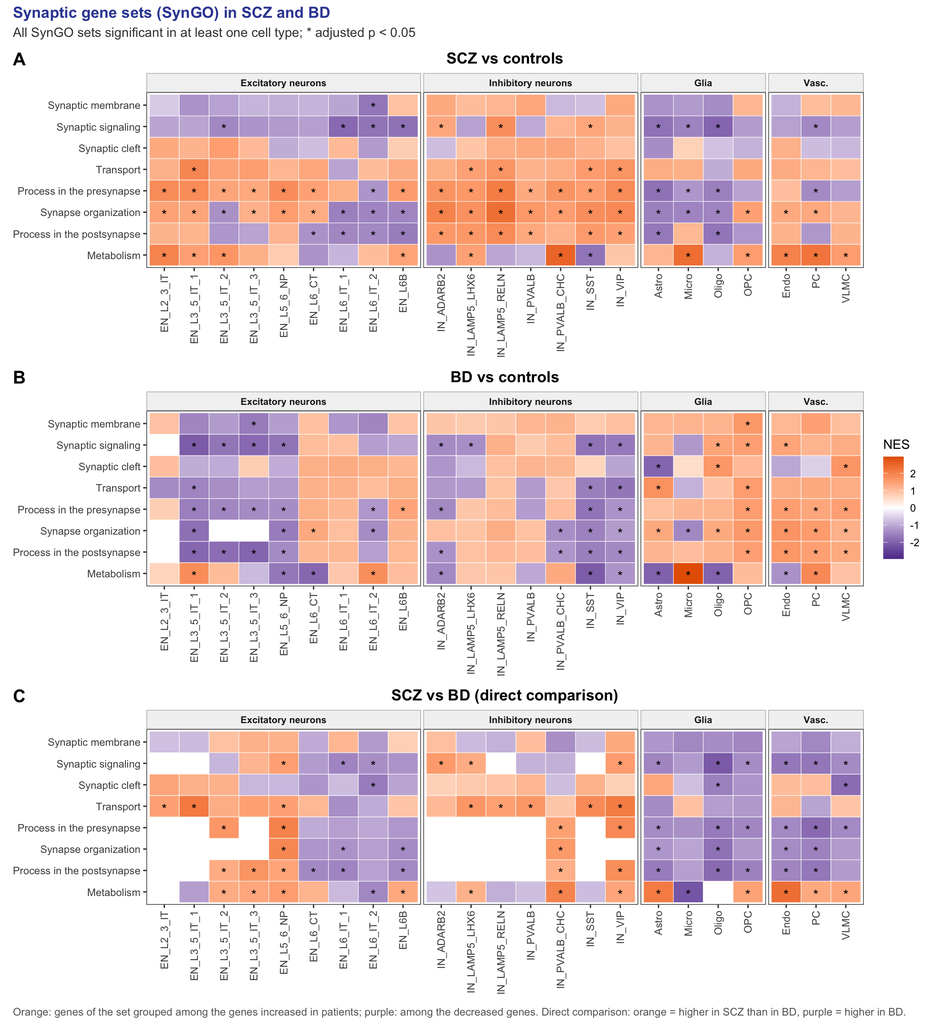

Figure 8

```r
p_F11 <- plot_gsea_heatmap(gsea_all, "SynGO", cell_order, n_sets = 20, alpha = alpha,
                           diseases = c("SCZ", "BD", "SCZ vs BD"), side_by_side = FALSE,
                           title = "Synaptic gene sets (SynGO) in SCZ and BD",
                           subtitle = "All SynGO sets significant in at least one cell type; * adjusted p < 0.05")
p_F11
save_figure(p_F11, "Q3_F11_SynGO", fig_dir, width = 11, height = 12)
```

**Figure Q3-F11 – Synaptic gene sets (SynGO) in SCZ and BD.** NES of the SynGO gene sets, per cell type grouped by family: (A) SCZ vs controls, (B) BD vs controls, (C) direct SCZ vs BD comparison (orange = higher in SCZ than in BD). * adjusted p < 0.05.

**TipHow to read**

Same reading as F07: orange = synaptic genes grouped among the genes increased in patients, purple = among the decreased genes. Compare panels A and B column by column; a star in panel C means that the two diseases differ for that synaptic function in that cell type.

**ImportantInterpretation**

- The synapse is where the two diseases **diverge most**, and where the cell types matter most.
- In SCZ, presynaptic processes and synapse organisation are shifted **up** in upper-layer neurons and interneurons, whereas synaptic signalling and the postsynapse are shifted **down** in deep-layer neurons (EN_L6B, EN_L6_CT, EN_L6_IT_1, EN_L6_IT_2).
- In BD, synaptic signalling, presynapse and postsynapse are shifted **down** in EN_L3_5_IT neurons (layers 3 to 5) and in interneurons (IN_SST, IN_VIP).
- The direct test confirms the difference in several neurons (EN_L5_6_NP, IN_PVALB_CHC, IN_VIP).
- In glial cells, synaptic sets are shifted down in SCZ (Astro, Micro, Oligo).

# Which results are found by both methods?

**What we do and why.** A pathway found by ORA (with a threshold on genes) **and** by GSEA (without threshold) is more reliable. For each cell type and disease, we compare the significant sets of the two methods.

```r
ora_all <- bind_rows(
  if (nrow(ora_go_table) > 0) mutate(ora_go_table, collection = "GO_BP"),
  ora_curated_table
)

concordance <- NULL
if (nrow(ora_all) > 0) {
  ora_sig <- ora_all |>
    mutate(disease = sub("_(up|down)$", "", Cluster)) |>
    distinct(collection, cell_type, disease, ID) |>
    mutate(in_ORA = TRUE)
  gsea_sig <- gsea_all |>
    filter(p.adjust < alpha, disease %in% c("SCZ", "BD")) |>
    distinct(collection, cell_type, disease = as.character(disease), ID) |>
    mutate(in_GSEA = TRUE)
  concordance <- full_join(ora_sig, gsea_sig, by = c("collection", "cell_type", "disease", "ID")) |>
    mutate(across(c(in_ORA, in_GSEA), ~ coalesce(.x, FALSE)),
           found_by = case_when(in_ORA & in_GSEA ~ "both", in_ORA ~ "ORA_only", TRUE ~ "GSEA_only"))
  write.csv(concordance, file.path(out_dir, "ora_gsea_concordance.csv"), row.names = FALSE)
  count(concordance, collection, found_by) |>
    pivot_wider(names_from = found_by, values_from = n, values_fill = 0)
}
```

| collection | GSEA_only | ORA_only | both |
| --- | --- | --- | --- |
| GO_BP | 16407 | 65 | 168 |
| Hallmark | 672 | 8 | 39 |
| Reactome | 4513 | 148 | 159 |
| SynGO | 151 | 1 | 3 |

**TipHow to read**

Number of significant sets found by both methods (`both`), by ORA only or by GSEA only. GO terms of the ORA were merged with `simplify()`, so the GO overlap is a lower bound.

**ImportantInterpretation**

- About 60 % of the functions found by ORA are also found by GSEA: the two methods agree on the strongest results.
- GSEA finds many more functions than ORA (`GSEA_only`), as expected: many small, coordinated changes do not pass the significance threshold of the genes.
- The functions found by both methods are the most robust and are preferred in the report (for example, in Hallmark: interferon responses in astrocytes and microglia; hypoxia, mTORC1 and TNFA signalling in glial and vascular cells).

# Conclusion

**ImportantSummary table**

| Element | Result | Figure |
| --- | --- | --- |
| Main functions over-represented among the significant genes (ORA) | mitochondrial energy production up in SCZ in deep-layer neurons; protein folding up in SCZ in microglia and vascular cells; few synaptic functions; almost never the same function in SCZ and BD | F02, F03 |
| Cell types with the most pathway changes | SCZ: upper-layer neurons (EN_L2_3_IT), CGE interneurons, glial and vascular cells; BD: deep-layer neurons (EN_L6B, EN_L6_IT), glial cells, pericytes | F06 |
| Main shared functions (same direction in SCZ and BD) | interferon responses, IL6/STAT3 and TNFA signalling, hypoxia, mTORC1, protein secretion, cell cycle; almost always shifted up; mostly in Astro, Micro, OPC and PC | F07, F08 |
| Functions that truly differ between SCZ and BD (direct test) | protein secretion, MYC targets, unfolded protein response higher in SCZ in upper-layer neurons and interneurons; hypoxia, mTORC1, TNFA signalling higher in BD in deep-layer neurons; synaptic sets | F08, F09, F11 |
| Are the overall pathway profiles of SCZ and BD similar? | yes in Astro, Micro, OPC and PC (rho 0.67–0.83); much less in neurons (rho 0.04–0.51) | F08 (B) |
| Gene-level overlap vs overlap of the genes driving shared pathways | significant genes: J ≈ 0.05; genes driving the shared pathways: J ≈ 0.4, twice the value expected by chance (≈ 0.2), significant in 20 of 23 cell types | F04, F10 |
| Results found by both ORA and GSEA | about 60 % of the ORA functions are also found by GSEA | table |
| Synaptic sets: direction and cell types | SCZ: up in upper-layer neurons and interneurons, down in deep-layer neurons; BD: down in EN_L3_5_IT neurons and interneurons; glia: down in SCZ | F11 |
| **Is H1 supported?** | **partly**: shared functions through partly shared genes, but only in glial and vascular cells; the two disorders differ at the synapse | F08, F10, F11 |

**Answer to Q3.** SCZ and BD share few significant genes (F04), but they converge on common biological functions (F07, F08). The convergence is strongest in glial and vascular cells: in astrocytes, microglia, OPC and pericytes, most altered gene sets are shared and the whole profiles are similar (rho 0.67–0.83). The shared functions are mainly inflammatory (interferon responses, IL6/STAT3, TNFA signalling), stress-related (hypoxia, protein folding) and growth-related (mTORC1). These shared pathways rest on a common core of driving genes, twice larger than expected by chance, plus genes specific to each disease (F10). Neurons, and above all the synapse, are where the two disorders diverge (F11).

**In one sentence:** SCZ and BD converge on inflammatory and stress pathways in glial and vascular cells, through partly shared genes, but diverge at the synapse of cortical neurons.

**Is H1 supported?** Partly. SCZ and BD do affect the same functions through only partly shared genes, as H1 predicts. But this convergence is limited to glial and vascular cells; for the synaptic functions targeted by the question, the two disorders differ.

**Our results in the light of the literature.** A partial convergence is what the genetics predict. SCZ and BD are the pair of brain disorders with the highest shared heritability in the PsychAD atlas, yet their transcriptomic similarity is only moderate, and lower than their genetic overlap would suggest [7]. Our results locate this partial convergence: it is found in glial and vascular cells, not in neurons.

The shared glial signal is mostly inflammatory. This agrees with the astrocyte gene module increased in both disorders in bulk cortex [10], and with the increase of inflammation in the DLPFC in SCZ, weaker in BD and mostly IL6/STAT3 [11], as in our data. Part of the shared stress signal is probably not specific to SCZ and BD: protein folding is one of the signatures shared by all eight brain disorders of the PsychAD atlas [7].

At the synapse, our SCZ results reproduce the layer pattern of the largest single-nucleus study of SCZ [12]: synaptic gene sets decreased in deep-layer excitatory neurons, but increased in upper-layer neurons. In astrocytes, the decrease of cholesterol homeostasis and synaptic gene sets in SCZ matches the synaptic neuron–astrocyte program, which declines in SCZ and with age [13]; this links Q3 to Q5. For BD, single-cell data are scarce; the decrease we observe at the synapse fits the enrichment of BD genetic risk in synaptic signalling genes [9], as for SCZ [8]. Finally, the decrease of oxidative phosphorylation in BD agrees with the mitochondrial module decreased in both disorders [10]; its increase in SCZ upper-layer neurons does not, and may reflect the cell-type resolution of our data.

**Links with the other questions.**

- **Q1 (composition)**: Microglia are fewer in both disorders (Q1), yet they share inflammatory pathways in SCZ and BD (F07, F08); this shift in expression is measured within the cell type, so it is not a consequence of the change in number.
- **Q2 (genes)**: The convergence is stronger at the level of functions than of genes: SCZ–BD similarity is higher for pathways than for fold changes in 18 of 23 cell types (F08).
- **Q4 (communication)**: Q4 finds changes in synaptic adhesion pathways (NRXN, NCAM, among others) and weaker GABAergic signalling, in line with the divergence of SCZ and BD at the synapse seen here; Q4 is exploratory (no donor-level test).
- **Q5 (ageing)**: Q5 finds an older-looking profile in several cell types, shared by SCZ and BD, but carried by the genes that change with normal ageing, not by the inflammation signatures: the shared glial inflammation of Q3 and the ageing-like profile of Q5 are two different signals.

# Limits

- **Dependence on Q2.** The enrichment inherits every bias of the DE analysis (covariates, number of donors per cell type).
- **Threshold of the ORA.** ORA results depend on the DEG cut-off; GSEA does not, which is why both are reported.
- **Redundancy of GO.** Even after merging similar terms, several GO terms can describe the same function, so one biological signal can appear several times in the results.
- **Annotation bias.** Well-studied genes belong to more gene sets and weigh more in the results.
- **RNA is not activity.** A pathway shifted at the RNA level does not prove a change in protein activity.
- **Medication.** Antipsychotics (SCZ) and lithium or mood stabilisers (BD) can change synaptic and metabolic genes on their own. A pathway that differs between SCZ and BD may reflect the treatment rather than the disease.
- **Almost all gene sets are shifted up.** Hypoxia, mTORC1 and stress pathways are up in most cell types. Part of this may be technical, because agonal factors such as hypoxia strongly modify post-mortem expression profiles [14], and stress signatures are shared by all brain disorders [7].
- **Bulk vs single cell.** Most published studies used bulk tissue; a difference with them may come from cell composition, not from expression within a cell type.
- **Ancestry.** In Q2, the SCZ results do not hold in donors of African ancestry only; ancestry is unbalanced between groups, and Q3 inherits this limit.
- **Power.** A disease with fewer donors has fewer significant pathways: “specific” may mean “not detected”. The direct SCZ vs BD test limits this risk, but it has less power than the comparisons with controls, and a non-significant direct test does not prove that the two diseases are identical.

# List of figures

All figures are saved as `.png` in `04_FIGURES/Q3_enrichment/`. Every table is saved in `03_RESULTS/Q3_enrichment/`.

| Figure | File | What it shows | Why we need it |
| --- | --- | --- | --- |
| — | `Q3_reasoning` | how the notebook answers Q3 | gives the logic before any result |
| F01 | `Q3_F01_ORA_overview` | significant genes and functions found by ORA, per cell type | shows where ORA has something to say, and its limits |
| F02 | `Q3_F02_ORA_GO_<family>` | GO functions over-represented among the significant genes, one panel per cell type | first answer to “which functions?”, close to the Q2 genes |
| F03 | `Q3_F03_ORA_<collection>_<family>` | same with Hallmark, Reactome and SynGO | checks that the GO results hold with other collections |
| F04 | `Q3_F04_DEG_overlap` | share of significant genes common to SCZ and BD | the gene-level overlap that H1 compares with the pathway level |
| F05 | `Q3_F05_GSEA_example` | one GSEA result in detail | lets the reader understand the NES and the leading edge, used in all the next figures |
| F06 | `Q3_F06_GSEA_counts_<collection>` | number of gene sets shifted up or down, per cell type and disease | answers “where?”: which cell types are the most affected at the level of functions |
| F07 | `Q3_F07_NES_heatmap_<collection>` | the 30 gene sets significant in the most cell types, in SCZ and BD | answers “which functions?”, and shows the shared ones |
| F08 | `Q3_F08_shared_specific` | shared vs specific gene sets per cell type, and similarity of the whole profiles | answers “together or separately?” with the right test |
| F09 | `Q3_F09_direct_SCZ_vs_BD` | direct SCZ vs BD comparison of the gene sets of F07 | names the functions that truly differ between the two diseases |
| F10 | `Q3_F10_leading_edge_overlap` | overlap of the genes driving the shared pathways, observed vs chance | **direct test of H1**: same function, same genes? |
| F11 | `Q3_F11_SynGO` | synaptic gene sets in SCZ, BD and SCZ vs BD | answers the synaptic part of the question |

```r
# Files actually created by this run
sort(list.files(fig_dir, pattern = "^Q3_F.*\\.png$"))
```

```
 [1] "Q3_F01_ORA_overview.png"          "Q3_F02_ORA_GO_EN.png"
 [3] "Q3_F02_ORA_GO_glia.png"           "Q3_F02_ORA_GO_IN.png"
 [5] "Q3_F02_ORA_GO_vascular.png"       "Q3_F03_ORA_Hallmark_EN.png"
 [7] "Q3_F03_ORA_Hallmark_glia.png"     "Q3_F03_ORA_Hallmark_IN.png"
 [9] "Q3_F03_ORA_Hallmark_vascular.png" "Q3_F03_ORA_Reactome_EN.png"
[11] "Q3_F03_ORA_Reactome_glia.png"     "Q3_F03_ORA_Reactome_IN.png"
[13] "Q3_F03_ORA_Reactome_vascular.png" "Q3_F03_ORA_SynGO_EN.png"
[15] "Q3_F03_ORA_SynGO_glia.png"        "Q3_F04_DEG_overlap.png"
[17] "Q3_F05_GSEA_example.png"          "Q3_F06_GSEA_counts_GO_BP.png"
[19] "Q3_F06_GSEA_counts_Hallmark.png"  "Q3_F06_GSEA_counts_Reactome.png"
[21] "Q3_F07_NES_heatmap_GO_BP.png"     "Q3_F07_NES_heatmap_Hallmark.png"
[23] "Q3_F07_NES_heatmap_Reactome.png"  "Q3_F08_shared_specific.png"
[25] "Q3_F09_direct_SCZ_vs_BD.png"      "Q3_F10_leading_edge_overlap.png"
[27] "Q3_F11_SynGO.png"
```

# References

1. HBC Training (Harvard Chan Bioinformatics Core). *Functional analysis of pseudobulk DE*: ORA with `enrichGO`, then GSEA with `GSEA()` and MSigDB gene sets from `msigdbr`, on pseudobulk DESeq2 results from single-cell data. https://hbctraining.github.io/Pseudobulk-for-scRNAseq-Quarto/lessons/10_functional_analysis_pseudobulk.html
2. Wu T. et al. (2021). clusterProfiler 4.0: a universal enrichment tool for interpreting omics data. *The Innovation*, 2, 100141.
3. Subramanian A. et al. (2005). Gene set enrichment analysis: a knowledge-based approach for interpreting genome-wide expression profiles. *PNAS*, 102, 15545–15550.
4. Zhou Y. et al. (2019). Metascape provides a biologist-oriented resource for the analysis of systems-level datasets. *Nature Communications*, 10, 1523. Default enrichment filters: p < 0.01, minimum count of 3, enrichment factor > 1.5.
5. Liberzon A. et al. (2015). The Molecular Signatures Database hallmark gene set collection. *Cell Systems*, 1, 417–425.
6. Koopmans F. et al. (2019). SynGO: an evidence-based, expert-curated knowledge base for the synapse. *Neuron*, 103, 217–234.
7. Lee D. et al. (2026). Single-cell atlas of transcriptomic vulnerability across brain disorders (PsychAD). *Nature*, 657, 988–1002. https://doi.org/10.1038/s41586-025-09573-z
8. Trubetskoy V. et al. (2022). Mapping genomic loci implicates genes and synaptic biology in schizophrenia. *Nature*, 604, 502–508.
9. Mullins N. et al. (2021). Genome-wide association study of more than 40,000 bipolar disorder cases provides new insights into the underlying biology. *Nature Genetics*, 53, 817–829.
10. Gandal M. J. et al. (2018). Shared molecular neuropathology across major psychiatric disorders parallels polygenic overlap. *Science*, 359, 693–697.
11. Lanz T. A. et al. (2019). Postmortem transcriptional profiling reveals widespread increase in inflammation in schizophrenia: a comparison of prefrontal cortex, striatum, and hippocampus among matched tetrads of controls with subjects diagnosed with schizophrenia, bipolar or major depressive disorder. *Translational Psychiatry*, 9, 151.
12. Ruzicka W. B. et al. (2024). Single-cell multi-cohort dissection of the schizophrenia transcriptome. *Science*, 384, eadg5136.
13. Ling E. et al. (2024). A concerted neuron–astrocyte program declines in ageing and schizophrenia. *Nature*, 627, 604–611.
14. Tomita H. et al. (2004). Effect of agonal and postmortem factors on gene expression profile: quality control in microarray analyses of postmortem human brain. *Biological Psychiatry*, 55, 346–352.